# Social Forecasting Tutorial 5

Martyn Egan

14/04/2023

# External Information and Binary Outcomes

Last week we looked at model-based methods in time series forecasting, including linear-type models and ARIMA. This week, we will look at how to add additional predictors to our models, as well as forecasting binary outcomes.

## Regression Models

Adding additional predictors to a time-series linear model is a relatively simple procedure. The `tslm()` function in the `forecast` package will accept additional variables in a similar manner to the `lm()` function in base `R`. We will use the `BikeSharingDaily.csv` dataset to demonstrate the procedure. The first code chunk is taken from the course reader, and is for preparing the data.

```r
# Load and prepare data.
bike.df <- read.csv("data/BikeSharingDaily.csv")
bike.df$Date <- as.Date(bike.df$dteday, format = "%Y-%m-%d")
bike.df$Month <- month(bike.df$Date, label = TRUE)
bike.df$DOW <- wday(bike.df$Date, label = TRUE)
bike.df$WorkingDay <- factor(bike.df$workingday, levels = c(0, 1), labels = c("Not_Working", "Working"))
bike.df$Weather <- factor(bike.df$weathersit, levels = c(1, 2, 3), labels = c("Clear", "Mist", "Rain_Snow"))

# Create dummy variables.
Month.dummies <- model.matrix(~ 0 + Month, data = bike.df)
DOW.dummies <- model.matrix(~ 0 + DOW, data = bike.df)
WorkingDay_Weather.dummies <- model.matrix(~ 0 + WorkingDay:Weather, data = bike.df)

# Change the names of the dummy variables.
colnames(Month.dummies) <- gsub("Month", "", colnames(Month.dummies))
colnames(DOW.dummies) <- gsub("DOW", "", colnames(DOW.dummies))
colnames(WorkingDay_Weather.dummies) <- gsub("WorkingDay", "", colnames(WorkingDay_Weather.dummies))
colnames(WorkingDay_Weather.dummies) <- gsub("Weather", "", colnames(WorkingDay_Weather.dummies))
colnames(WorkingDay_Weather.dummies) <- gsub(":", "_", colnames(WorkingDay_Weather.dummies))

# Set up training and validation sets.
x <- as.data.frame(cbind(Month.dummies[, -12], DOW.dummies[, -7], WorkingDay_Weather.dummies[, -6]))
y <- bike.df$cnt
nTotal <- length(y)
nValid <- 90
nTrain <- nTotal - nValid
xTrain <- x[1:nTrain, ]
yTrain <- y[1:nTrain]
xValid <- x[(nTrain + 1):nTotal, ]
yValid <- y[(nTrain + 1):nTotal]
```

The above code wrangles the `.csv` file into an appropriate format for our regression model: numerical data are transformed into correctly formatted factors; dummy variables are created for month and day of week to model seasonality; additional vectors are created with external information, consisting of a cross-combination of working day and weather. Finally, the data are split into train and validate sets. Note that our target, `y`, is now a separate object to our predictor variables.

```r
head(xTrain)
```

```
##   Jan Feb Mar Apr May Jun Jul Aug Sep Oct Nov Sun Mon Tue Wed Thu Fri
## 1   1   0   0   0   0   0   0   0   0   0   0   0   0   0   0   0   0
## 2   1   0   0   0   0   0   0   0   0   0   0   1   0   0   0   0   0
## 3   1   0   0   0   0   0   0   0   0   0   0   0   1   0   0   0   0
## 4   1   0   0   0   0   0   0   0   0   0   0   0   0   1   0   0   0
## 5   1   0   0   0   0   0   0   0   0   0   0   0   0   0   1   0   0
## 6   1   0   0   0   0   0   0   0   0   0   0   0   0   0   0   1   0
##   Not_Working_Clear Working_Clear Not_Working_Mist Working_Mist
## 1                 0             0                1            0
## 2                 0             0                1            0
## 3                 0             1                0            0
## 4                 0             1                0            0
## 5                 0             1                0            0
## 6                 0             1                0            0
##   Not_Working_Rain_Snow
## 1                     0
## 2                     0
## 3                     0
## 4                     0
## 5                     0
## 6                     0
```

The next stage is to create a `ts` object from the target variable, `y`, and to run a regression model with our predictor variables, `xTrain`.

```r
yTrain.ts <- ts(yTrain) #create ts object

(formula <- as.formula(paste("yTrain.ts", paste(c("trend", colnames(xTrain)), collapse = "+"), sep = "~"))) #create a formula object to pass to tslm
```

```
## yTrain.ts ~ trend + Jan + Feb + Mar + Apr + May + Jun + Jul +
##     Aug + Sep + Oct + Nov + Sun + Mon + Tue + Wed + Thu + Fri +
##     Not_Working_Clear + Working_Clear + Not_Working_Mist + Working_Mist +
##     Not_Working_Rain_Snow
```

```r
bike.tslm <- tslm(formula, data = xTrain, lambda = 1)
options(scipen = 999, digits = 6)
summary(bike.tslm)
```

```
##
## Call:
## tslm(formula = formula, data = xTrain, lambda = 1)
##
## Residuals:
##    Min     1Q Median     3Q    Max
##  -3197   -390     47    450   3743
##
## Coefficients:
##                       Estimate Std. Error t value             Pr(>|t|)
## (Intercept)            -483.43     330.21   -1.46               0.1437
## trend                     6.28       0.18   34.84 < 0.0000000000000002 ***
## Jan                     296.66     172.94    1.72               0.0868 .
## Feb                     542.60     174.94    3.10               0.0020 **
## Mar                    1423.11     171.91    8.28  0.00000000000000078 ***
## Apr                    2075.00     172.88   12.00 < 0.0000000000000002 ***
## May                    2682.19     171.03   15.68 < 0.0000000000000002 ***
## Jun                    2780.76     171.95   16.17 < 0.0000000000000002 ***
## Jul                    2406.31     171.51   14.03 < 0.0000000000000002 ***
## Aug                    2322.29     172.12   13.49 < 0.0000000000000002 ***
## Sep                    2418.41     172.19   14.04 < 0.0000000000000002 ***
## Oct                    1715.85     194.09    8.84 < 0.0000000000000002 ***
## Nov                     833.77     198.45    4.20  0.00003043204899398 ***
## Sun                    -364.19     114.82   -3.17               0.0016 **
## Mon                    -632.85     207.41   -3.05               0.0024 **
## Tue                    -492.70     231.53   -2.13               0.0337 *
## Wed                    -495.55     229.81   -2.16               0.0314 *
## Thu                    -422.88     229.57   -1.84               0.0659 .
## Fri                    -413.30     227.78   -1.81               0.0701 .
## Not_Working_Clear      1492.13     293.09    5.09  0.00000047346122692 ***
## Working_Clear          1969.21     219.67    8.96 < 0.0000000000000002 ***
## Not_Working_Mist        971.77     306.89    3.17               0.0016 **
## Working_Mist           1279.92     222.83    5.74  0.00000001452898551 ***
## Not_Working_Rain_Snow -1728.35     461.55   -3.74               0.0002 ***
## ---
## Signif. codes:  0 '***' 0.001 '**' 0.01 '*' 0.05 '.' 0.1 ' ' 1
##
## Residual standard error: 773 on 617 degrees of freedom
## Multiple R-squared:  0.844,  Adjusted R-squared:  0.838
## F-statistic:  145 on 23 and 617 DF,  p-value: <0.0000000000000002
```

Note that the model contains a coefficient for `trend`, which is the daily trend component calculated by the `tslm()` function. The additional coefficients are linear components for seasonality (month and day of week), and weather/workday. Note that there is a reference category for each to avoid collinearity, i.e. the intercept can be defined as a Saturday in December which is a working day and raining/snowing (is this a credible combination? What implications might this have for the model?)

```r
bike.tslm.pred <-  forecast(bike.tslm, newdata = xValid)
accuracy(bike.tslm.pred, yValid)
```

```
##                                    ME     RMSE      MAE        MPE     MAPE
## Training set   -0.0000000000000525472  758.546  564.165   -4.84598  18.3665
## Test set     -584.2936780542937640348 1662.391 1175.905 -282.77445 291.3016
##                  MASE     ACF1
## Training set 0.806851 0.363076
## Test set     1.681741       NA
```

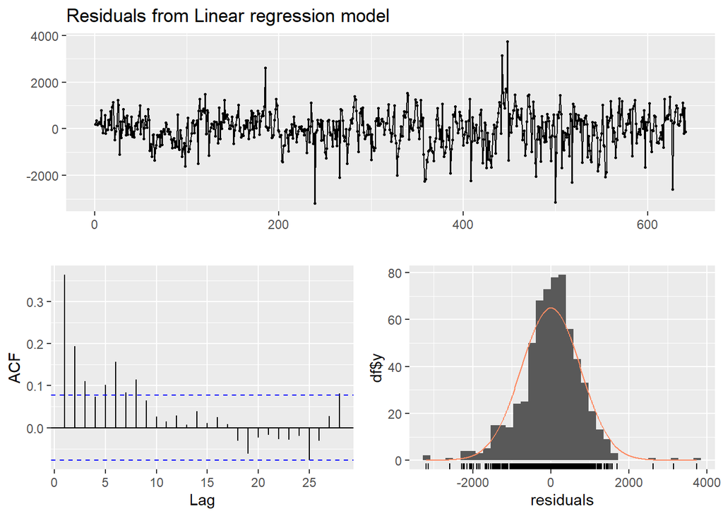

```
##
##  Ljung-Box test
##
## data:  Residuals from Linear regression model
## Q* = 159.4, df = 10, p-value <0.0000000000000002
##
## Model df: 0.   Total lags used: 10
```

```r
checkresiduals(bike.tslm.pred)
```

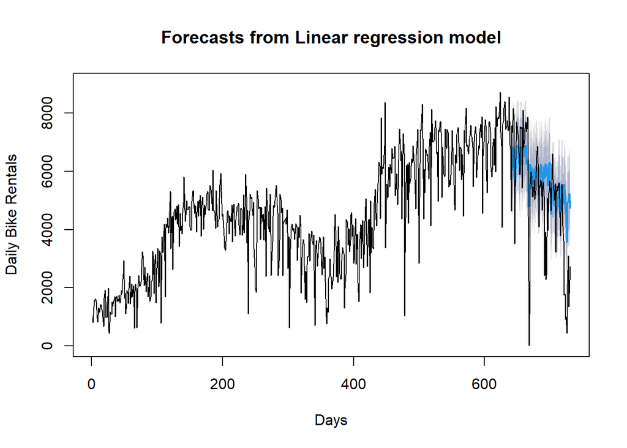

```r
y.ts<- ts(y)
times.ts <- time(y.ts)

plot(bike.tslm.pred, ylim = c(0, 9000), xlab = "Days", ylab = "Daily Bike Rentals")
lines(window(y.ts, start = times.ts[nValid + 1]))
```

How do we interpret the output? The Ljung-Box test is highly significant, which suggests the residuals are not white noise. Looking at the Acf, we can see high levels of autocorrelation within the first few lags. This often happens with long time series, but suggests that there is information which the linear model isn’t capturing. Looking at the forecast as well, the errors are quite large. Can we do better?

## Dynamic Regression

Dynamic regression allows us to incorporate the benefits of ARIMA within a multivariate time series regression. Similarly to the AR method we saw last week, dynamic regression essentially models the residuals (the error term) as an ARIMA process. Let’s compare the models.

```r
bike.dyn <- auto.arima(yTrain, xreg = as.matrix(xTrain)) #xreg requires a matrix

bike.dyn.pred <- forecast(bike.dyn, xreg = as.matrix(xValid)) #xreg functions here like the newdata arg

accuracy(bike.dyn.pred, yValid)
```

```
##                        ME     RMSE      MAE        MPE     MAPE     MASE
## Training set    -0.472632  705.849  513.386   -5.06209  16.8342 0.734228
## Test set     -1508.460383 2314.708 1750.859 -332.62221 335.7880 2.504022
##                     ACF1
## Training set -0.00449897
## Test set              NA
```

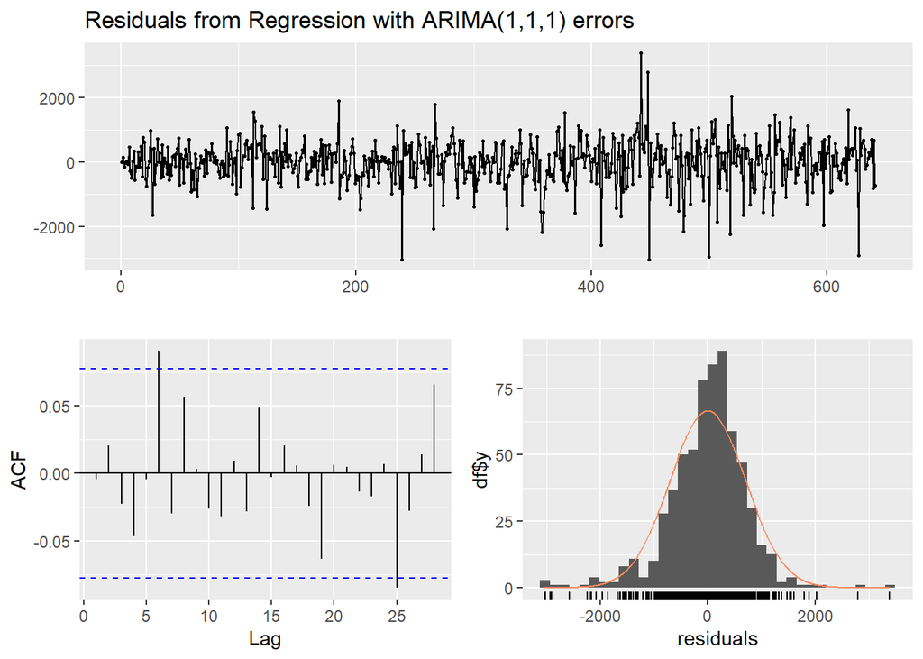

```
##
##  Ljung-Box test
##
## data:  Residuals from Regression with ARIMA(1,1,1) errors
## Q* = 10.43, df = 8, p-value = 0.236
##
## Model df: 2.   Total lags used: 10
```

```r
checkresiduals(bike.dyn.pred)
```

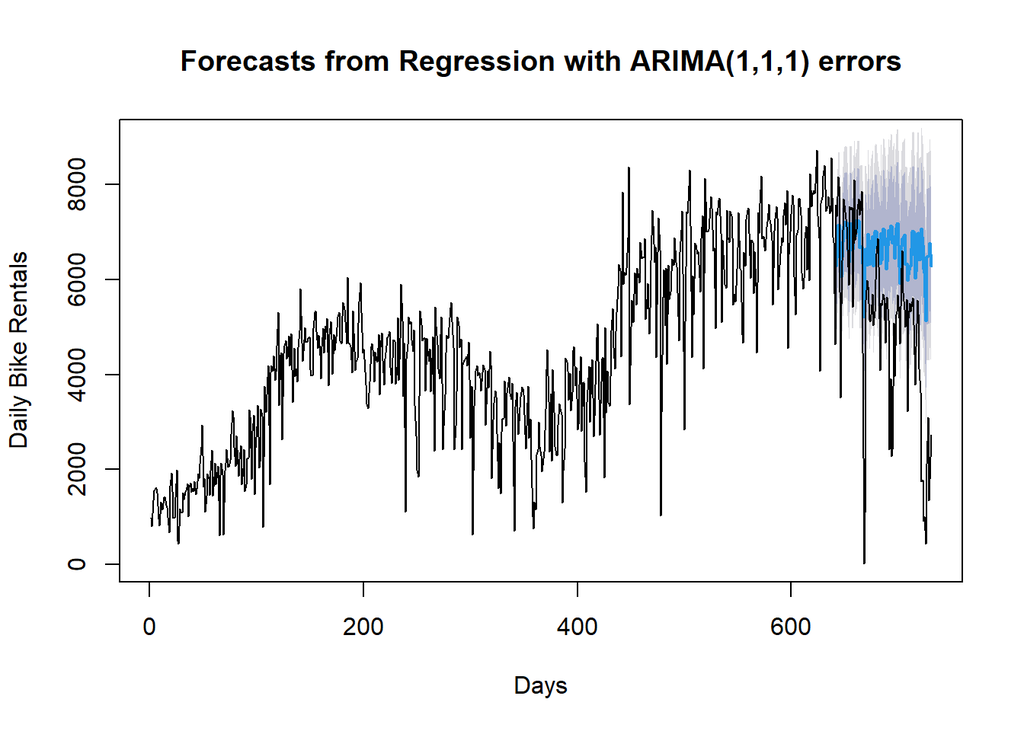

```r
plot(bike.dyn.pred, ylim = c(0, 9000), xlab = "Days", ylab = "Daily Bike Rentals")
lines(window(y.ts, start = times.ts[nValid + 1]))
```

Dynamic Regression seems to do a worse job “out of the box” here. Remember though how our data are highly seasonal, which can affect ARIMA. Perhaps if we used a different process (rather than dummy variables) to model seasonality, dynamic regression might perform better?

## Dynamic Harmonic Regression

Similarly to the sin and cosine transformations for seasonality we looked at briefly last week, dynamic harmonic regression allows us to incorporate multivariate seasonal data within an ARIMA model, through what are known as Fourier terms. Fourier terms have a value, *K*, which cannot be more than half the seasonal period, and which essentially indicates how smooth or jagged the seasonality should be. Fourier terms allow for large seasonality to be included (e.g. 365 days, etc.)

```r
# First, we create an msts (a ts with multiple seasonality), here days and months
Train.msts <- msts(y[1:nTrain], seasonal.periods = c(7, 28))
Valid.msts <- msts(y[(nTrain + 1):nTotal], seasonal.periods = c(7, 28))

# Then we run the regression with fourier terms
bike.dyn.ha <- auto.arima(Train.msts, xreg = cbind(fourier(Train.msts, K = c(3, 11)),
                                               as.matrix(xTrain[,18:22])), seasonal = FALSE)

bike.dyn.ha.pred <- forecast(bike.dyn.ha, xreg = cbind(fourier(Valid.msts,
                                                               K = c(3, 11),
                                                               h = 90),
                                                       as.matrix(xValid[,18:22])))

accuracy(bike.dyn.ha.pred, yValid)
```

```
##                         ME     RMSE      MAE        MPE    MAPE     MASE
## Training set     0.0645789  702.195  508.741   -4.54618  16.710 0.727585
## Test set     -2565.7639389 3219.161 2657.009 -392.04396 393.204 3.799969
##                     ACF1
## Training set -0.00123798
## Test set              NA
```

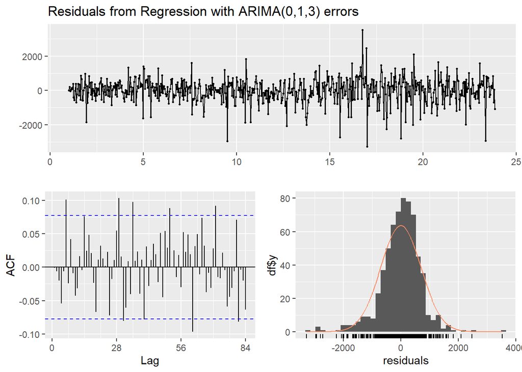

```
##
##  Ljung-Box test
##
## data:  Residuals from Regression with ARIMA(0,1,3) errors
## Q* = 71.79, df = 53, p-value = 0.0438
##
## Model df: 3.   Total lags used: 56
```

```r
checkresiduals(bike.dyn.ha.pred)
```

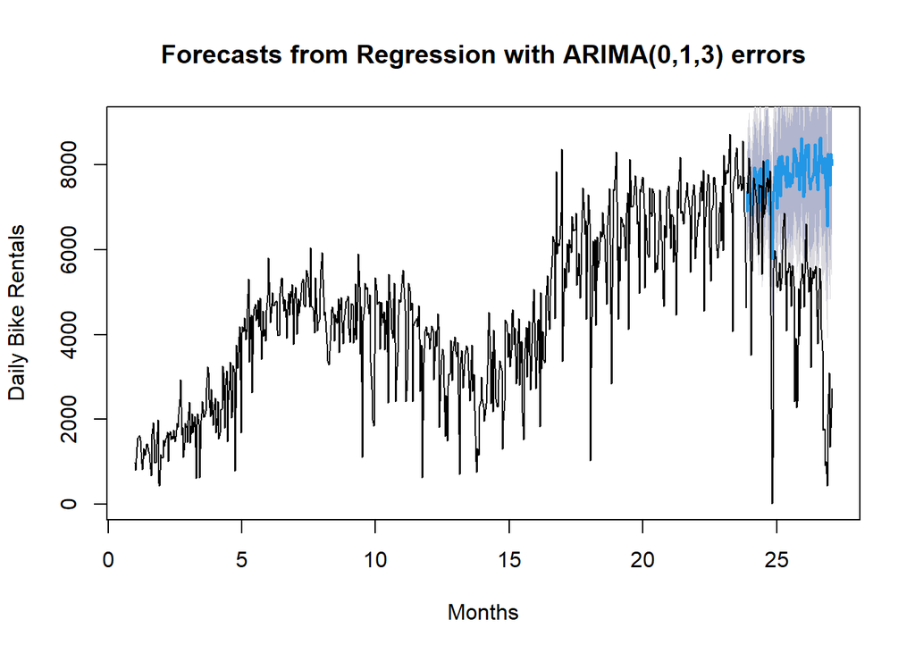

```r
new.msts <- msts(c(rep(NA, 641), Valid.msts), seasonal.periods = c(7,28))

plot(bike.dyn.ha.pred, ylim = c(0, 9000), xlab = "Months", ylab = "Daily Bike Rentals")
lines(window(new.msts))
```

Here, dynamic harmonic regression performs quite badly: notice that it is difficult to fit precise calendar months within a Fourier term; also, we are possibly losing too much information by dropping the other variables from the model (month and day of the week). Fourier models assume that seasonality does not evolve over time, which in this case is probably too strong an assumption. Remember that if we want to incorporate some of the benefits of autoregression in our model, we could also train an AR(1) model on the errors from our linear model, as in last week’s class.

## Binary Outcomes

The final forecasting technique we will look at concerns binary outcomes. As with cross-sectional data, the technique used here is logistic regression, in which we model the relationship between the odds of the event of interest and the predictors. For forecasting purposes, we select a cutoff value above which the prediction is 1.

As with other forecasting methods, lagged predictors (where available) can be useful in forecasting binary outcomes: when the binary outcome is based on a continuous measurement (stock price, blood sugar, rainfall, etc.) it can be more useful to include the lagged predictor of the actual measurement, rather than the binary value.

The below example uses the `MelbourneRainfall.csv` dataset to forecast rainy days (yes/no) using only rainfall amounts. We use the `glm()` function, with which you are already familiar, to model binary outcomes; it is not necessary to convert the data frame to a time series object for use with `glm()`. We do however perform several operations such as lagging and the use of seasonal smoothing. We will also use the `caret` package to create a confusion matrix of forecast outcomes.

```r
rain <- read.csv("data/MelbourneRainfall.csv")

rain$Date <- as.Date(rain$Date, format = "%d/%m/%Y")
rain$Rainy <- ifelse(rain$Rainfall > 0, 1, 0)

rain$Lag1 <- c(NA, rain$Rainfall[1:nrow(rain)-1])
rain$t <- seq(1, nrow(rain), 1)

rain$Seasonal_sine <- sin(2*pi*rain$t/365.25)
rain$Seasonal_cosine <- cos(2*pi*rain$t/365.25)

train <- rain[rain$Date <= as.Date("31/12/2009", format = "%d/%m/%Y"), ]
train <- train[-1,]
valid <- rain[rain$Date > as.Date("31/12/2009", format = "%d/%m/%Y"), ]

rainy.mod <- glm(Rainy ~ Lag1 + Seasonal_sine + Seasonal_cosine,
                 data = train,
                 family = "binomial")

summary(rainy.mod)
```

```
##
## Call:
## glm(formula = Rainy ~ Lag1 + Seasonal_sine + Seasonal_cosine,
##     family = "binomial", data = train)
##
## Deviance Residuals:
##    Min      1Q  Median      3Q     Max
## -2.857  -0.932  -0.751   1.312   1.723
##
## Coefficients:
##                 Estimate Std. Error z value             Pr(>|z|)
## (Intercept)      -0.7689     0.0386  -19.93 < 0.0000000000000002 ***
## Lag1              0.1119     0.0114    9.84 < 0.0000000000000002 ***
## Seasonal_sine    -0.2688     0.0505   -5.32     0.00000010128789 ***
## Seasonal_cosine  -0.3713     0.0507   -7.33     0.00000000000023 ***
## ---
## Signif. codes:  0 '***' 0.001 '**' 0.01 '*' 0.05 '.' 0.1 ' ' 1
##
## (Dispersion parameter for binomial family taken to be 1)
##
##     Null deviance: 4751.8  on 3651  degrees of freedom
## Residual deviance: 4533.7  on 3648  degrees of freedom
## AIC: 4542
##
## Number of Fisher Scoring iterations: 4
```

```r
rainy.pred <- predict(rainy.mod, valid[, c(4, 6, 7)], type = "response")

confusionMatrix(as.factor(ifelse(rainy.mod$fitted > 0.5, 1, 0)),
                as.factor(train$Rainy),
                positive = "1")
```

```
## Confusion Matrix and Statistics
##
##           Reference
## Prediction    0    1
##          0 2251 1115
##          1  104  182
##
##                Accuracy : 0.666
##                  95% CI : (0.651, 0.682)
##     No Information Rate : 0.645
##     P-Value [Acc > NIR] : 0.00357
##
##                   Kappa : 0.117
##
##  Mcnemar's Test P-Value : < 0.0000000000000002
##
##             Sensitivity : 0.1403
##             Specificity : 0.9558
##          Pos Pred Value : 0.6364
##          Neg Pred Value : 0.6687
##              Prevalence : 0.3551
##          Detection Rate : 0.0498
##    Detection Prevalence : 0.0783
##       Balanced Accuracy : 0.5481
##
##        'Positive' Class : 1
##
```

```r
confusionMatrix(as.factor(ifelse(rainy.pred > 0.5, 1, 0)),
                as.factor(valid$Rainy),
                positive = "1")
```

```
## Confusion Matrix and Statistics
##
##           Reference
## Prediction   0   1
##          0 373 220
##          1  21  55
##
##                Accuracy : 0.64
##                  95% CI : (0.602, 0.676)
##     No Information Rate : 0.589
##     P-Value [Acc > NIR] : 0.00404
##
##                   Kappa : 0.165
##
##  Mcnemar's Test P-Value : < 0.0000000000000002
##
##             Sensitivity : 0.2000
##             Specificity : 0.9467
##          Pos Pred Value : 0.7237
##          Neg Pred Value : 0.6290
##              Prevalence : 0.4111
##          Detection Rate : 0.0822
##    Detection Prevalence : 0.1136
##       Balanced Accuracy : 0.5734
##
##        'Positive' Class : 1
##
```

As the confusion matrix demonstrates, the model is quite accurate at predicting no-rain days (94.7% - the specificity score) and about 20% accurate at predicting rarer rainy days (sensitivity).

## A Final Word on External Information…

When using external information (i.e. additional predictors) to forecast time series data, we always need to think about the real life scenario in which the model will be used.

Take the bike rental case above: it’s clear that there is some *thing* which is leading to a sharp fall in demand that none of our models is capturing. What could this omitted variable be?

Perhaps more importantly, think about the external information we’re using. What variable in our model could be problematic for *forecasting* demand? How might we better model this uncertainty in our forecast?

### Case Study

The `bicup2006.csv` dataset contains historic information on passengers arriving at a public bus terminal in five-minute periods for a three-week window. Your goal is to create a model with the best predictive metrics, using a two-week training period and a one week validation period.

```r
bicup <- read.csv("data/bicup2006.csv")
```